# rOpenSci onboarding system for packages

Maëlle Salmon, co-editor at rOpenSci

2017-07-03

# What is rOpenSci?

- Presented in David’s talk… can I quizz you?
- An organization supporting open science and reproducibility
- Packages and a community

[figure not shown]

# Onboarding?

- Internally developed packages (Scott Chamberlain, Jeroen Ooms).
- Packages submitted by the community.

https://ropensci.org/packages/

Onboarding process: ensuring best practices in the collection of packages.

# Onboarding?

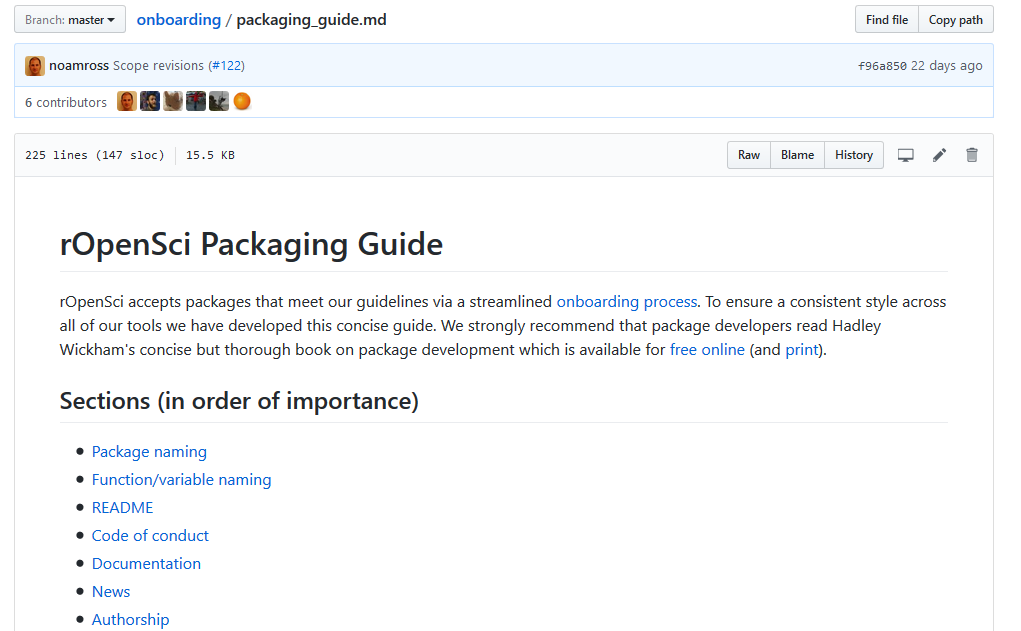

# What packages?

- **data retrieval**
- **data extraction**
- **database access**
- **data munging**
- **data deposition**
- **reproducibility**

# What packages?

- **geospatial data**
- **text analysis**

And in case of any doubt… pre-submission enquiries!

# Who?

Four editors

- Scott Chamberlain (@sckottie)
- Karthik Ram (@_inundata)
- Noam Ross (@noamross)
- Maëlle Salmon (@ma_salmon)

And many awesome reviewers!

# Submission story: `ropenaq`

- Step 1: reading old issues until I felt ready and not afraid

You don’t need that step, coolest process ever!

# Submission story: `ropenaq`

- Step 2: submitting the package!

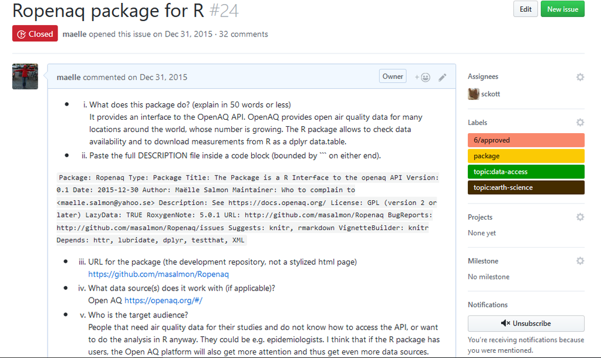

# Submission story: `ropenaq`

- Step 3: getting the reviews and making the changes

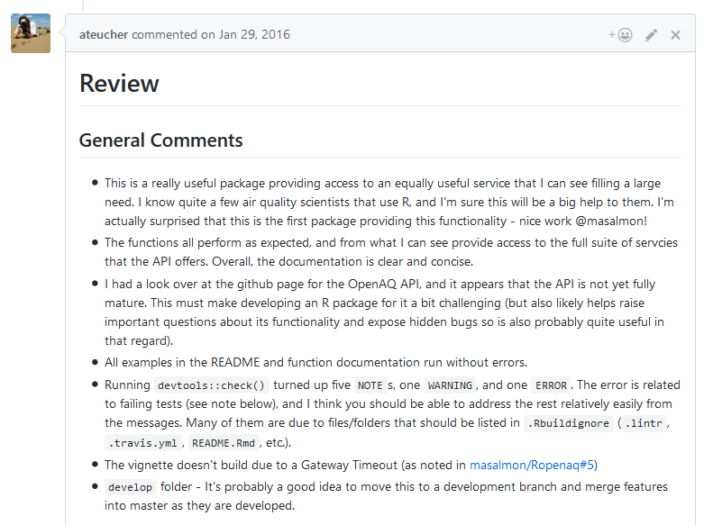

# Submission story: `ropenaq`

- Step 4: thanking the reviewers and transferring the repo

[figure not shown]

# Submission story: `ropenaq`

- Step 5: writing a blog post

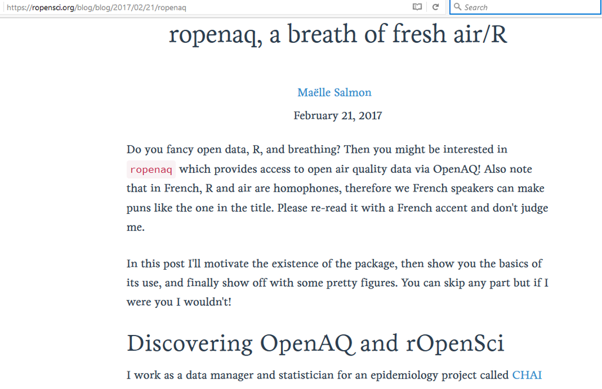

# Submission story: `ropenaq`

- The package got better
- My coding skills got better
- I met nice people

What’s not to love about that process?

# Why is this interesting for you?

- Submitting a package?
- Becoming a reviewer?

# Where to get more information

- The Github onboarding repo github.com/ropensci/onboarding
- Ask me anything!